# Data Science – Midterm report

### Building a Regression Model

#### 1. Introduction to the domain-specific area

Salmon and its species, as with many animals, come in different shapes and sizes. Of the 5 pacific salmon species in the dataset, we can quickly understand the size (length / weight) attributes as per internet sources:

- Chinook: Adult fish range in size from 61 to 91 cm, but may be up to 150 cm in length; they average 4.5 to 22.7 kg, but may reach 59 kg[1]
- Chum: Adult chum salmon usually weigh from 4.4 to 10.0 kg with an average length of 60.0 cm[2]
- Coho: Mature adults average 71 cm and 3.2 to 5.0 kg, occasionally reaching up to 16 kg[3]
- Pink: Pink salmon average 2.2 kg in weight. The maximum recorded size was 76 cm and 6.8 kg[4]
- Sockeye: Sockeye can be anywhere from 60 to 84 cm in length and weigh from 2.3 to 7 kg[5]

As we can see from the general description, the 5 species of pacific salmon differ in length and weight. And that will also produce a unique length to weight ratio. Although the of the salmon is quite similar at around 60+ cm for all 5 species, the weight differs quite a bit between each species. Although this report will not focus specifically on the internal biological differences, we can generally understand the variance to be attributed to the difference in bone density, skin thickness, fat content, internal organ size, width of salmon, etc.

The below picture can provide a visual reference to the size difference between these 5 species[6].

[figure not shown]

Even before looking at the data, we can quickly understand that there are obvious physical differences between the 5 species of salmon. Specifically, the Chinook salmon is much larger than the others. The pink salmon appears the be the smallest.

A possible application for the prediction of weight of a salmon within a wild and natural habitat is to provide more datapoints for species identification. An example of a similar solution has been deployed in Norway where an AI powered filtering system is used to filter out invasive species of salmon[8]. The system needs to identify and categorize the salmon into either the local Atlantic salmon or invasive Pacific salmon to allow or deny access to the upstream channel.

In this case of this, the camera can be set up to capture the length of the sample, but gathering the weight would be difficult in a real-life environment due to many variables. When the weight is predicted, the length of the sample with the predicted weight could be used in another machine learning classification model (perhaps logistical regression) to predict the species of salmon.

#### Description of the selected dataset

The dataset acquired from Kaggle describes it as “60 years of measurements from 12.5 million salmon across Alaska”. It also attributes the data to another source [9].

The dataset can be described as biological data of salmon samples collected in Alaska from 1922-2017. In total, the dataset includes just over 14.3 million samples (14,347,460 actual entries) of salmon covering 5 pacific species -- chinook, chum, coho, pink and sockeye.

The dataset also includes 27 columns of data including age, sex and length, weight, sample date, measurement method, saltwater/ freshwater age, and other classification data. As can be expected for such a large dataset spanning over 60 years of sampling carried out by multiple teams with differing technology available at the time, the completeness of the data varies across all aspect. Luckily, with so many samples, discarding incomplete samples to gather usable data can still yield a favorable sample size for the project.

The columns of interest for this project:

- Species
- Sample year
- Sample date
- Length
- Weight
- Sex
- Data source

The first task was to analyze the raw dataset in using pandas. We can load it from the CSV file into a data frame and print the head using df_salmon1.head()

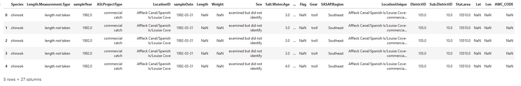

From the screenshot, we can see that the dataset includes 27 columns of information, but not all will be usable in the context of this project. What we really interested in is the values length, weight, sex, and age. We can further filter out the dataset to see roughly how many rows are usable by checking the invalid data in the weight column with df_salmon1.isna().sum()

So, we can see that in the Weight column, it returned just over 13.6 million rows that are not usable for this project. 14,347,460 – 13,670,088 = 677,372 usable entries

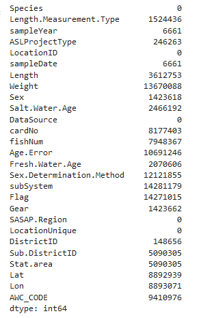

Perhaps, after further data cleaning, we will end up with less than ~677k entries, but it has been decided that this specific dataset is for this project is suitable and should yield a good cleaned up amount of data.

### Objectives of the project

The objective of this project is to use the length data of the specific salmon species to predict the weight. Length and weight datapoints will be gathered from the dataset and filtered down to a desired manageable dataset with all the required datapoints present.

The processed data will be used for the Scikit-learn regression model based on the Support Vector Regression, which is great for working with continuous values. Length data will be inputted and weight will be predicted by the model.

When implemented, it can augment existing classification machine learning models by adding an extra layer of data verification. Ideally, this would be used early on when gathering data, like mentioned in the example of the similar solution has been deployed as an AI powered salmon filtering system in Norway, it can help in gathering real time data of the length of the sample salmon and predict the weight for further classification models downstream.

The advantage is that it can predict and provide real time data for models and allow the classification models to better classify according to live data.

## Data processing

```python
# All purpose import for processing
import numpy as np
import pandas as pd

# Visualisation
import matplotlib.pyplot as plt
import seaborn as sns
import matplotlib

# Time manipulation
import datetime
```

```python
# read the CSV dataset
df_salmon1 = pd.read_csv('ASL_master.csv')

print('Columns in df:', *df_salmon1.columns, sep=' ')
print('Shape:', df_salmon1.shape)

df_salmon1.head()
```

```
Columns in df: Species Length.Measurement.Type sampleYear ASLProjectType LocationID sampleDate Length Weight Sex Salt.Water.Age DataSource cardNo fishNum Age.Error Fresh.Water.Age Sex.Determination.Method subSystem Flag Gear SASAP.Region LocationUnique DistrictID Sub.DistrictID Stat.area Lat Lon AWC…
Shape: (14347461, 27)
```

|  | Species | Length.Measurement.Type | sampleYear | ASLProjectType | LocationID | sampleDate | Length | Weight | Sex | Salt.Water.Age | ... | Flag | Gear | SASAP.Region | LocationUnique | DistrictID | Sub.DistrictID | Stat.area | Lat | Lon | AWC_CODE |
| --- | --- | --- | --- | --- | --- | --- | --- | --- | --- | --- | --- | --- | --- | --- | --- | --- | --- | --- | --- | --- | --- |
| 0 | chinook | length not taken | 1992.0 | commercial catch | Affleck Canal/Spanish Is/Louise Cove | 1992-03-31 | NaN | NaN | examined but did not identify | 3.0 | ... | NaN | troll | Southeast | Affleck Canal/Spanish Is/Louise Cove-commercia... | 105.0 | 10.0 | 10510.0 | NaN | NaN | NaN |
| 1 | chinook | length not taken | 1992.0 | commercial catch | Affleck Canal/Spanish Is/Louise Cove | 1992-03-31 | NaN | NaN | examined but did not identify | 3.0 | ... | NaN | troll | Southeast | Affleck Canal/Spanish Is/Louise Cove-commercia... | 105.0 | 10.0 | 10510.0 | NaN | NaN | NaN |
| 2 | chinook | length not taken | 1992.0 | commercial catch | Affleck Canal/Spanish Is/Louise Cove | 1992-03-31 | NaN | NaN | examined but did not identify | 3.0 | ... | NaN | troll | Southeast | Affleck Canal/Spanish Is/Louise Cove-commercia... | 105.0 | 10.0 | 10510.0 | NaN | NaN | NaN |
| 3 | chinook | length not taken | 1992.0 | commercial catch | Affleck Canal/Spanish Is/Louise Cove | 1992-03-31 | NaN | NaN | examined but did not identify | 3.0 | ... | NaN | troll | Southeast | Affleck Canal/Spanish Is/Louise Cove-commercia... | 105.0 | 10.0 | 10510.0 | NaN | NaN | NaN |
| 4 | chinook | length not taken | 1992.0 | commercial catch | Affleck Canal/Spanish Is/Louise Cove | 1992-03-31 | NaN | NaN | examined but did not identify | 4.0 | ... | NaN | troll | Southeast | Affleck Canal/Spanish Is/Louise Cove-commercia... | 105.0 | 10.0 | 10510.0 | NaN | NaN | NaN |

5 rows × 27 columns

```python
print(df_salmon1.dtypes)
```

```
Species                      object
Length.Measurement.Type      object
sampleYear                  float64
ASLProjectType               object
LocationID                   object
sampleDate                   object
Length                      float64
Weight                      float64
Sex                          object
Salt.Water.Age              float64
DataSource                   object
cardNo                       object
fishNum                      object
Age.Error                    object
Fresh.Water.Age             float64
Sex.Determination.Method     object
subSystem                    object
Flag                         object
Gear                         object
SASAP.Region                 object
LocationUnique               object
DistrictID                  float64
Sub.DistrictID              float64
Stat.area                   float64
Lat                         float64
Lon                         float64
AWC_CODE                     object
dtype: object
```

```python
df_salmon1.isna().sum()
```

```
Species                            0
Length.Measurement.Type      1524436
sampleYear                      6661
ASLProjectType                246263
LocationID                         0
sampleDate                      6661
Length                       3612753
Weight                      13670088
Sex                          1423618
Salt.Water.Age               2466192
DataSource                         0
cardNo                       8177403
fishNum                      7948367
Age.Error                   10691246
Fresh.Water.Age              2070606
Sex.Determination.Method    12121855
subSystem                   14281179
Flag                        14271015
Gear                         1423662
SASAP.Region                       0
LocationUnique                     0
DistrictID                    148656
Sub.DistrictID               5090305
Stat.area                    5090305
Lat                          8892939
Lon                          8893071
AWC_CODE                     9410976
dtype: int64
```

```python
df_salmon1 = df_salmon1.dropna(subset=['Weight', 'Length', 'sampleYear', 'Salt.Water.Age', 'Fresh.Water.Age'])
len(df_salmon1.index)
```

```
497906
```

```python
df_salmon1 = df_salmon1[df_salmon1['Weight'] != 0]
df_salmon1 = df_salmon1[df_salmon1['Length'] != 0]
df_salmon1.drop(df_salmon1[df_salmon1.Length > 5000].index, inplace=True)
df_salmon1.drop(df_salmon1[df_salmon1.Length < 350].index, inplace=True)
df_salmon1.drop(df_salmon1[df_salmon1.Weight < 0.2].index, inplace=True)
len(df_salmon1.index)
```

```
283296
```

```python
df_salmon1["Species"].value_counts()
```

```
sockeye    193483
pink        31480
chinook     29028
chum        26308
coho         2997
Name: Species, dtype: int64
```

Pre-processing was done in pandas with the whole 3.5 GB datafile loaded as a single data frame. Using the requirements for the processed data, we will need filter out rows of data that is not usable in the context of our project.

Specific parameters were decided as requirements, and any entries that did not have the full requirements were discarded. The most have data points were:

- Species
- sampleYear
- Length
- Weight
- Salt.Water.Age
- Fresh.Water.Age

The next step was to handle the weight column. Officially the values should be in kilograms, but after inspection, it is noticed that the values are a mix of kg and grams.

a.) After dropping all invalid rows, a few seaborn plots were created to get an idea of the distribution of data.

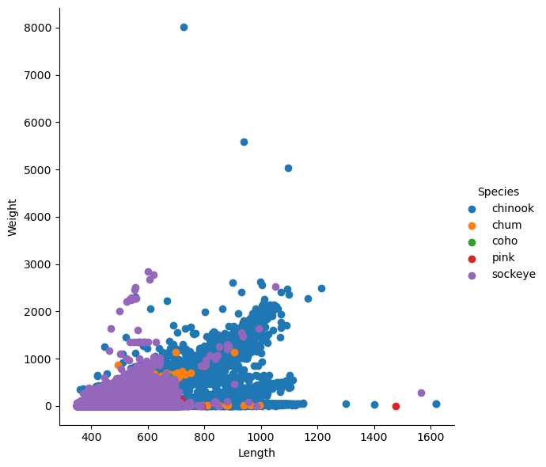

```python
sns.FacetGrid(df_salmon1, hue="Species", height=6).map(plt.scatter, "Length", "Weight").add_legend()
```

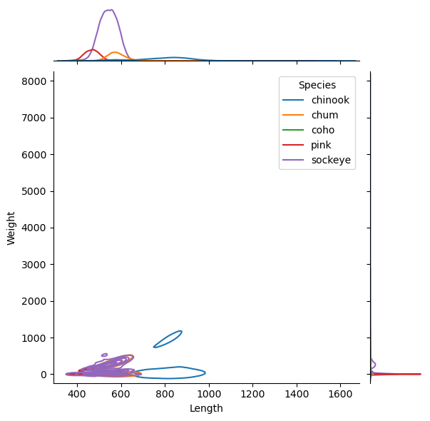

```python
sns.jointplot(
    data=df_salmon1,
    x="Length", y="Weight", hue="Species",
    kind="kde"
)
```

So, from this scatter plot and jointplot, we can interpret that the Weight value is grouped into a mix of 3 measurement standards. As predicted, some of the values are recorded in different units which can cause issues:

1. grams, e.g., 773, 2780
2. kg, e.g., 5.41, 5.63
3. uninterpretable e.g., 50, 63, 139

```python
df_salmon_weight = (df_salmon1[df_salmon1.Weight < 33 ])
len(df_salmon_weight.index)
```

```
154593
```

After dropping all values over 33 for "Weight", as dictated by the average of a Chinook and upper limit if what can be possible, we gather all the rows under 33 so we can capture the kg values.

The reason for this is below 33 shows 154 thousand rows and can fix issue #3 of interpretable data.

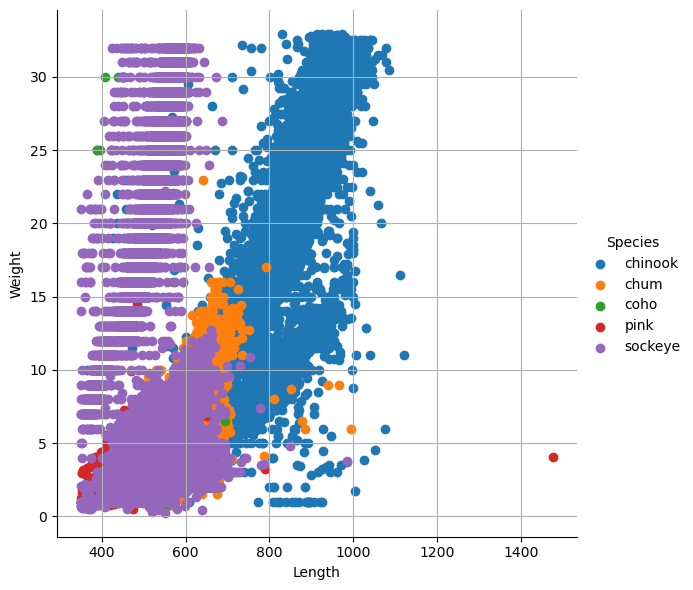

```python
sns.FacetGrid(df_salmon_weight, hue="Species", height=6).map(plt.scatter, "Length", "Weight").add_legend()
plt.grid()
```

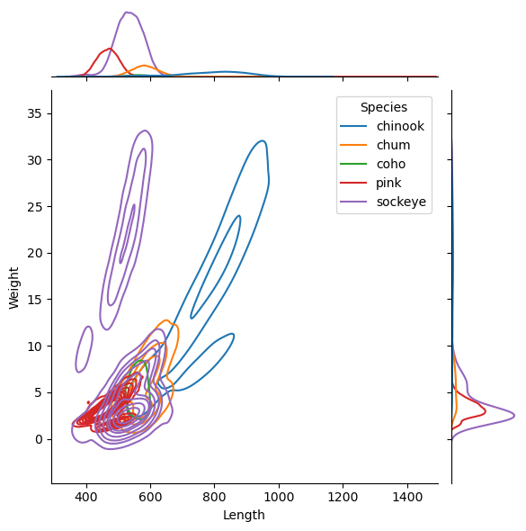

```python
sns.jointplot(
    data=df_salmon_weight,
    x="Length", y="Weight", hue="Species",
    kind="kde"
)
```

After plotting the new dataframe on a scatter plot, we can see that there are more issues with the kg unit data.

The outlier values on the top left shown in purple for sockeye looks to be human made values and not natural. It is speculated that it is either a data gathering inaccuracy, or data recording inaccuracy.

The fact that most of it falls into whole numbers, like 10, 11, 12 shows that it is not naturally occurring. This is actually a repeat issue for all species. We will need to filter that out as it is deemed as faulty data.

Some conditions were created to filter out the faulty data. Mainly using a combination of length and weight conditions.

```python
df_salmon_weight.drop(df_salmon_weight[(df_salmon_weight["Length"] < 600) & (df_salmon_weight["Weight"] > 13)|
                                       (df_salmon_weight["Length"] < 650) & (df_salmon_weight["Weight"] > 15)|
                                        (df_salmon_weight["Length"] < 570) & (df_salmon_weight["Weight"] > 11)|
                                       (df_salmon_weight["Length"] < 500) & (df_salmon_weight["Weight"] > 10)|
                                       (df_salmon_weight["Length"] < 455) & (df_salmon_weight["Weight"] > 7)|
                                       (df_salmon_weight["Length"] < 425) & (df_salmon_weight["Weight"] > 6)|
                                      (df_salmon_weight["Length"] > 700) & (df_salmon_weight["Weight"] < 2)
                                      ].index, inplace=True)
len(df_salmon_weight.index)
```

```
142177
```

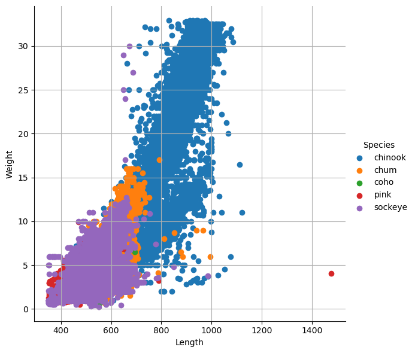

```python
sns.FacetGrid(df_salmon_weight, hue="Species", height=6).map(plt.scatter, "Length", "Weight").add_legend()
plt.grid()
```

After trimming the unnatural values, the cleaned-up data looks much better and should be ready to be used as such.

The next step is to identify a range of years that provide a good spread of salmon data. Ideally, the data should span multiple years as to gather more variance in collecting methods and not reply on one sample size.

At the moment, 142 thousand rows of data is too much, and we would try and trim it down to maybe 1000 samples. We can do this and keep the data more consistent and relevant by focusing on a particular timeframe of the provided data.

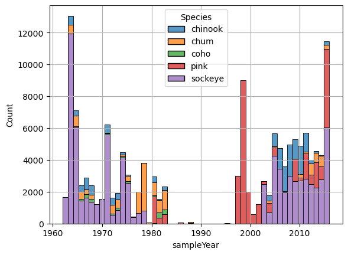

```python
sns.histplot(data=df_salmon_weight, x="sampleYear", hue="Species",multiple="stack", bins= 51)
plt.grid()
```

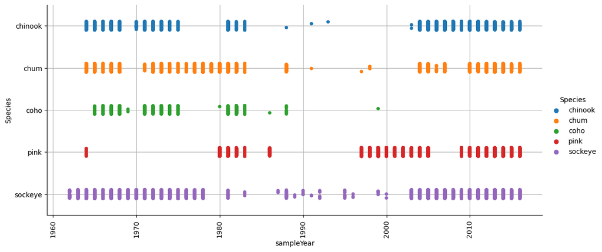

```python
sns.catplot(x="sampleYear", y="Species", hue="Species",data=df_salmon_weight, aspect=9/4)
plt.xticks(rotation=90) # rotate the x-axis labels
plt.grid()
plt.show()
```

The above catplot and hisplot shows that the only timeframe that fits our requirements is around the late 1970s early 1980s, which is where we have data for all 5 species within the same year +/- a few years.

So, we will apply some conditions to grab the rows within our set parameters of samples falling within our predefined requirements as below.

```python
df_salmon_weight.drop(df_salmon_weight[(df_salmon_weight["sampleYear"] < 1972)|
                                         (df_salmon_weight["sampleYear"] > 1983)|
                                        (df_salmon_weight["sampleYear"] == 1976)|
                                        (df_salmon_weight["sampleYear"] == 1977)|
                                        (df_salmon_weight["sampleYear"] == 1978)].index, inplace=True)
len(df_salmon_weight.index)
```

```
17929
```

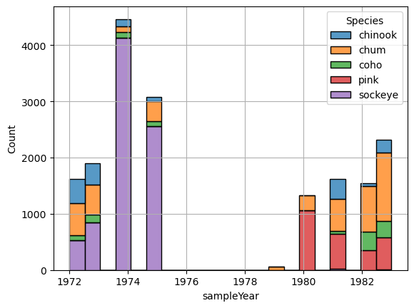

```python
sns.histplot(data=df_salmon_weight, x="sampleYear", hue="Species",multiple="stack")
plt.grid()
```

```python
df_salmon_weight["Species"].value_counts()
```

```
sockeye    8099
chum       4472
pink       2614
chinook    1667
coho       1077
Name: Species, dtype: int64
```

For the regression model, it is decided that chinook will be the species to use for the training and testing data. The reason for this is the higher variance and spread in length and weight.

We would still need to deal with the different units of weight measurement still present in our dataset. One method is to extract the weight to length ratio and drop all samples in the lower path of the trend line. We will create another column to store that number for further processing.

```python
df_salmon_weight['Ratio'] = df_salmon_weight['Weight'] / df_salmon_weight['Length']
df_salmon_weight['Ratio']
```

```
80667       0.018382
80668       0.028962
80669       0.032511
80670       0.031180
80672       0.033024
              ...
13065727    0.011335
13065728    0.015457
13065729    0.011607
13065731    0.013189
13065732    0.011679
Name: Ratio, Length: 17929, dtype: float64
```

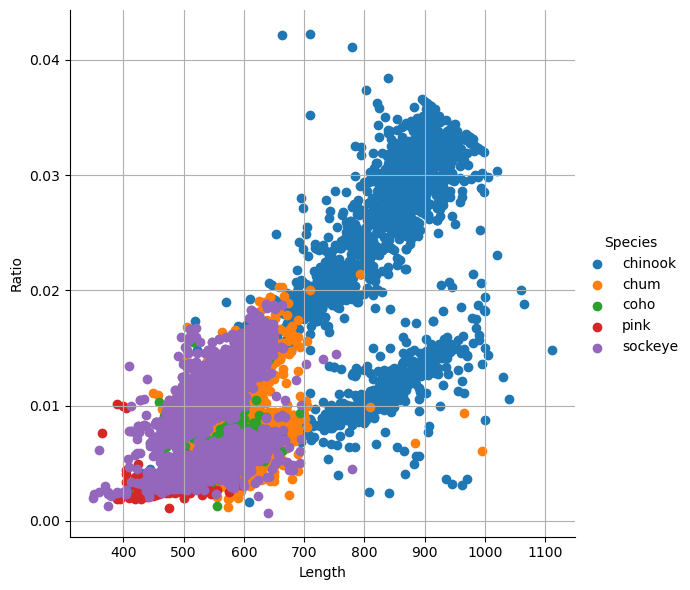

```python
sns.FacetGrid(df_salmon_weight, hue="Species", height=6).map(plt.scatter, "Length", "Ratio").add_legend()
plt.grid()
```

From the scatter plot, we can see that the ratio also follows the same trend line, so we can use that value to discard unwanted data.

But first, we will need to extract the chinook only samples and create a new dataframe.

```python
df_salmon_weight_chinook = df_salmon_weight.loc[(df_salmon_weight['Species'] == "chinook")]
len(df_salmon_weight_chinook.index)
```

```
1667
```

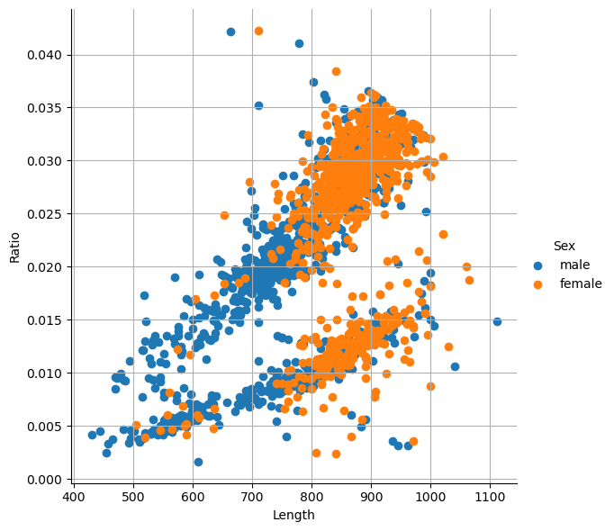

```python
sns.FacetGrid(df_salmon_weight_chinook, hue="Sex", height=6).map(plt.scatter, "Length", "Ratio").add_legend()
plt.grid()
```

As previously mentioned, we will use some conditions to remove the faulty data according to the ration and the length. It could be understood as the lower trend line roughly with the ratio of 0.005 to 0.015.

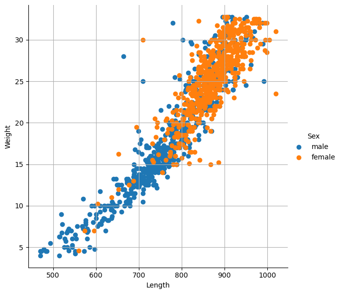

```python
df_salmon_weight_chinook.drop(df_salmon_weight_chinook[
    (df_salmon_weight_chinook["Ratio"] < 0.0075) & (df_salmon_weight_chinook["Length"] < 1200) |
    (df_salmon_weight_chinook["Ratio"] < 0.01) & (df_salmon_weight_chinook["Length"] > 600) |
    (df_salmon_weight_chinook["Ratio"] < 0.0135) & (df_salmon_weight_chinook["Length"] > 700) |
     (df_salmon_weight_chinook["Ratio"] < 0.017) & (df_salmon_weight_chinook["Length"] > 800 ) |
    (df_salmon_weight_chinook["Ratio"] < 0.023) & (df_salmon_weight_chinook["Length"] > 900 )].index, inplace=True)

sns.FacetGrid(df_salmon_weight_chinook, hue="Sex", height=6).map(plt.scatter, "Length", "Weight").add_legend()
plt.grid()
```

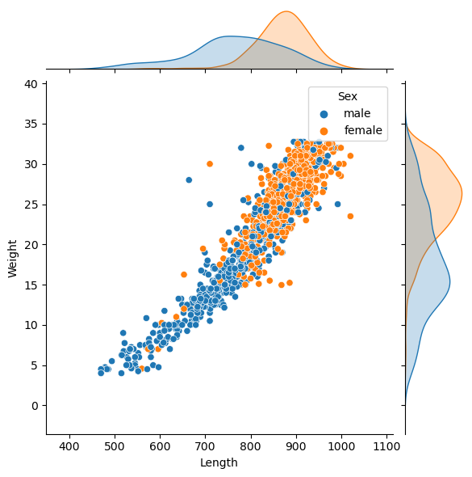

```python
sns.jointplot(
    data=df_salmon_weight_chinook,
    x="Length", y="Weight", hue="Sex", height=6
)
```

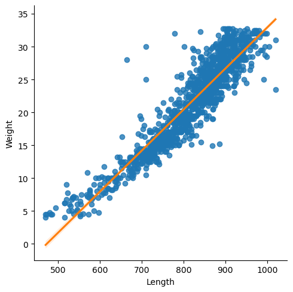

```python
# drawing linear regression models
sns.lmplot(x ='Length', y ='Weight', line_kws={"color": "C1"}, data = df_salmon_weight_chinook)
```

```python
len(df_salmon_weight_chinook.index)
```

```
1168
```

We can see that the result is quite satisfactory and the trend line appears to be more standard and consistent with only one unit for the weight values.

The linear regression model was also ploted to give a general idea of the regression line.

We also ended up with 1168 chinook samples after processing for the machine learning model.

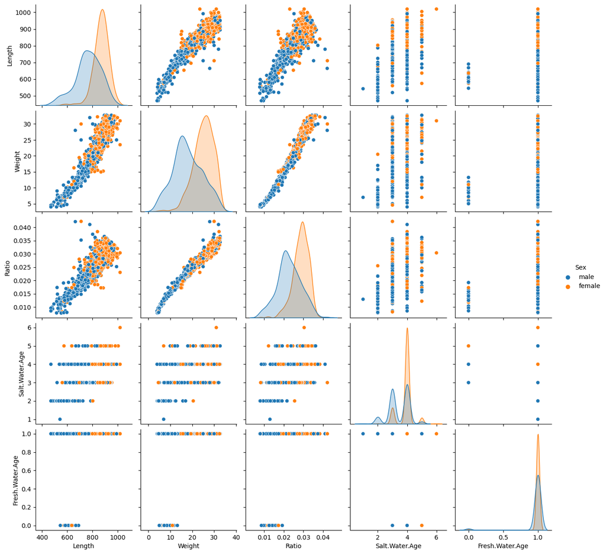

```python
plt.figure()
sns.pairplot(df_salmon_weight_chinook[['Length', 'Weight', "Ratio", 'Salt.Water.Age', 'Fresh.Water.Age', 'Species', "Sex"]], hue = 'Sex')
plt.show()
```

We can try and visualize the relation between all the datapoints that we have to work with using the above pairplot. We can also verify the accuracy of the data in relation to the other data points to see if something is off.

Some interesting things to note:

- Female chinook salmon samples show higher values for length and weight
- Salt water age shows increasing length and weight values as the age increases

At this point, we can consider that the current data we have is cleaned and all unwanted / faulty data has been discarded. This means we are ready to move onto the next section.

## Machine learning section

For the machine learning part, I have decided to use the Support Vector Regression (SVR) method to create a regression model. The reason for selecting this method is for a few reasons:

- SVR is a version of the already popular SVM for regression
- Supported by scikit-learn library with choice of multiple implementation methods
- SVR performs better performance prediction than other algorithms like Linear Regression, KNN and Elastic Net [10]

As stated in the beginning, the goal is to predict the weight of a new sample of salmon according to the species of salmon with the length.

- Label (y value) would be the weight of the salmon sample
- Feature (X value) would be the length of the salmon

The reason for selecting the labels and features is due to our hypothetical situation of the AI salmon species identification, we can only gather the length of the salmon in real time.

```python
# import scikit-learn libraries
from sklearn import svm
from sklearn.svm import SVR
from sklearn import model_selection
from statsmodels.tools.eval_measures import mse
from sklearn.model_selection import train_test_split
from sklearn import metrics
from sklearn.metrics import mean_squared_error, mean_absolute_error, r2_score, accuracy_score

from sklearn.ensemble import RandomForestRegressor
from sklearn.datasets import make_regression
```

### ML model #1

```python
# declare X and y values with selected columns from dataframe
X = df_salmon_weight_chinook[['Length']].values
y = df_salmon_weight_chinook[['Weight']].values
```

```python
# split the dataset into train and test sets
X_train, X_test, y_train, y_test = train_test_split(X, y, test_size=0.2, random_state=11)
```

Create the SVR model with the code and insert the traning data

```python
h1=svm.SVR()
h1.fit(X_train, np.ravel(y_train))
```

```
SVR()
```

Now, we will create a y_pred that will store the prediction of the values using the already trained model

```python
y_pred=h1.predict(X_test)
```

We can view the predicted values inside the y_pred by printing the first 5 items. We will also print the actual y_test data underneath.

The predicted values are actually not far off from the real values, but we will use some other metrics and visualizations to interpret the y_pred performance.

```python
print(y_pred[0:5])
print(y_test[0:5])
```

```
[16.27228022 25.94305144 28.31280509 27.29239085 23.54801008]
[[15.5]
 [24. ]
 [27. ]
 [23.5]
 [22.5]]
```

Now, we will print out 3 popular metrics for evaluating our SVR model:

- R2 score — the proportion of the variance in the dependent variable that is predictable from the independent variable(s)[11]. Closer to 1 = better
- Mean Absolute Error — a measure of errors between paired observations expressing the same phenomenon[12]. Lower = better
- Root Mean Squared Error —a measure of the differences between values (sample) predicted by a model or an estimator and the values observed[13]. Lower = better

```python
print("R^2 : ", r2_score(y_test, y_pred))
print("MAE :", mean_absolute_error(y_test,y_pred))
print("RMSE:", np.sqrt(mean_squared_error(y_test, y_pred)))
```

```
R^2 :  0.8758345801347762
MAE : 1.6563926368987276
RMSE: 2.3034140936259306
```

We can also plot the outputs into scatter plots of visualization of the performance.

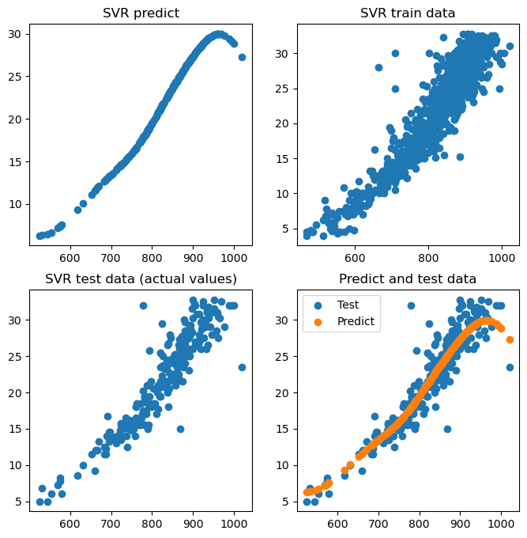

```python
# use matplotlib to make a 2 by 2 array of plots
fig, axs = plt.subplots(2,2, figsize=(8, 8))
axs[0, 0].scatter(X_test,y_pred)
axs[0, 0].set_title('SVR predict')
axs[0, 1].scatter(X_train,y_train)
axs[0, 1].set_title('SVR train data')
axs[1, 0].scatter(X_test,y_test)
axs[1, 0].set_title('SVR test data (actual values)')
axs[1, 1].scatter(X_test,y_test, label="Test")
axs[1, 1].scatter(X_test,y_pred, label ="Predict")
plt.legend(loc='upper left')
axs[1, 1].set_title('Predict and test data')
```

The results are not bad, but the y_predict starts to veer off at the higher length values. Maybe it is the lack of upper range data and outlier value that is throwing it off.

Lets see if we can improve the model by adding one more label – Sex. This is selected for the fact that in the pairplot graph, the variance between male and female was quite high and maybe this extra label can make the model more robust.

### ML model #2

```python
# map female and male to integers
salmon_maping = {'female': 0, 'male':1}
df_salmon_weight_chinook["Sex2"] = df_salmon_weight_chinook["Sex"].map(salmon_maping)
```

```python
# declare X and y values with selected columns from dataframe
X2 = df_salmon_weight_chinook[['Length', 'Sex2']].values
y2 = df_salmon_weight_chinook[['Weight']].values
X2_train, X2_test, y2_train, y2_test = train_test_split(X2, y2, test_size=0.2, random_state=11)
```

```python
h2=svm.SVR()
h2.fit(X2_train, np.ravel(y2_train))
```

```
SVR()
```

```python
y2_pred=h2.predict(X2_test)
```

```python
print(y2_pred[0:5])
print(y2_test[0:5])
```

```
[17.07673634 25.22911156 27.41638191 33.01343313 23.21533967]
[[15.5]
 [24. ]
 [27. ]
 [23.5]
 [22.5]]
```

```python
#use list comprehension to get the 0th item from every array
X2_test_length = [item[0] for item in X2_test]
X2_train_length = [item[0] for item in X2_train]

print("R^2 : ", r2_score(y2_test, y2_pred))
print("MAE :", mean_absolute_error(y2_test,y2_pred))
print("RMSE:", np.sqrt(mean_squared_error(y2_test, y2_pred)))
```

```
R^2 :  0.8603931637132937
MAE : 1.7218641073185295
RMSE: 2.4424463434472092
```

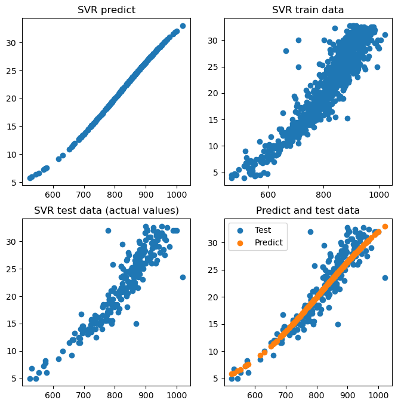

```python
# use matplotlib to make a 2 by 2 array of plots
fig, axs = plt.subplots(2,2, figsize=(8, 8))
axs[0, 0].scatter(X2_test_length,y2_pred)
axs[0, 0].set_title('SVR predict')
axs[0, 1].scatter(X2_train_length,y2_train)
axs[0, 1].set_title('SVR train data')
axs[1, 0].scatter(X2_test_length,y2_test)
axs[1, 0].set_title('SVR test data (actual values)')
axs[1, 1].scatter(X2_test_length,y2_test, label="Test")
axs[1, 1].scatter(X2_test_length,y2_pred, label ="Predict")
plt.legend(loc='upper left')
axs[1, 1].set_title('Predict and test data')
```

## Conclusions

The results of the both SVR models matched the actual values quite closely. It is believed that if deployed in the above-mentioned scenario of the AI salmon species identification, weight could be predicted to an accurate degree which closely follows the actually regression line.

The metrics for both ML model #1 and ML model #2 are quite similar in terms of R^2, MAE, and RMSE, but the visual data showed a slight difference. The ML model #2 performed slightly better at the higher end of the features (x value) input.

The project overall was a success in achieving the original goal mentioned in the first part of the report. Most of the effort was spent on the processing of the data. It is believed that unprocessed data would not be able to achieve this result, but at the same time, the highly processed data already fit the regression line before the application of machine learning model. Perhaps the data may have been too processed, which resulted in a favorable result. Maybe with enough time, it is worth exploring an alternate control scenario by providing the ML models with less processed data and interpreting the results.

Appendix:

1. https://en.wikipedia.org/wiki/Chinook_salmon#Description
2. https://en.wikipedia.org/wiki/Chum_salmon#Distribution
3. https://en.wikipedia.org/wiki/Coho_salmon#Description
4. https://en.wikipedia.org/wiki/Pink_salmon#Description
5. https://en.wikipedia.org/wiki/Sockeye_salmon#Description
6. https://commons.wikimedia.org/wiki/File:FMIB_44715_Five_Species_of_Pacific_Salmon_Photographed_to_Scale,_Also_Showing_Weight_of_Each.jpeg
7. http://robinbarefield.com/pacific-salmon/
8. https://www.ksn.com/business/press-releases/cision/20220824CN49678/huawei-and-partners-install-worlds-first-ai-filtering-system-for-salmon-in-a-natural-river-in-norway/
9. (Jeanette Clark, Rich Brenner, and Bert Lewis. 2018. Compiled age, sex, and length data for Alaskan salmon, 1922-2017. KNBdoi:10.5063/F1707ZTM.) https://knb.ecoinformatics.org/view/doi:10.5063/F1707ZTM
10. https://medium.com/analytics-vidhya/support-vector-regression-svr-model-a-regression-based-machine-learning-approach-f4641670c5bb
11. https://en.wikipedia.org/wiki/Coefficient_of_determination
12. https://en.wikipedia.org/wiki/Mean_absolute_error
13. https://en.wikipedia.org/wiki/Root-mean-square_deviation